# Pulsed NMR Individual Analysis

Use this template to carry out the analysis tasks for the Noise experiment. For reference, here are links to recommended Python resources: the [Whirlwind Tour of Python](https://jakevdp.github.io/WhirlwindTourOfPython/) and the [Python Data Science Handbook](https://jakevdp.github.io/PythonDataScienceHandbook/) both by Jake VanderPlas.

There is no need to calculate uncertainties for this analysis. The goals here are only to see and understand general trends. You may want to use the [LMFit](https://lmfit.github.io/lmfit-py/) package.

```python
# Run this cell with Shift-Enter, and wait until the asterisk changes to a number, i.e., [*] becomes [1]
import numpy as np
import scipy.constants as const
import uncertainties as unc
from uncertainties import unumpy as unp
import matplotlib.pyplot as plt
import pandas as pd
%matplotlib inline
```

Note: we chose to complete experiments 1, 3, and 4.

## Import data tables

Display them so that you know they are correct.

```python
exp3 = pd.read_csv("nmr data - echopos (2).csv")
exp3
### Note on data: we took a second trial on a different lab period,
# but this data was scaled relative to our first trial, so it
# didn't make sense to include it with this data set. Even so,
# we found roughly the same value for D.
```

|  | Delay time (ms) | Echo height (V) 1 | Echo height (V) 2 |
| --- | --- | --- | --- |
| 0 | 1.0 | 3.640 | 3.640 |
| 1 | 5.0 | 3.300 | 3.560 |
| 2 | 10.0 | 3.500 | 3.420 |
| 3 | 20.0 | 2.400 | 2.380 |
| 4 | 30.0 | 0.980 | 1.040 |
| 5 | 35.0 | 0.360 | 0.400 |
| 6 | 37.0 | 0.188 | 0.176 |
| 7 | 38.5 | 0.136 | 0.136 |

## Experiment 3: diffusion study

### Massage the collected data

Rescale the **Delay_time** data to give the echo-position time.

```python
exp3['echo pos (ms)'] = 2 * exp3['Delay time (ms)']
exp3['Echo height (V)'] = unp.uarray(exp3.iloc[:, [1,2]].mean(axis=1), \
                                     exp3.iloc[:, [1,2]].std(axis=1))
exp3
```

|  | Delay time (ms) | Echo height (V) 1 | Echo height (V) 2 | echo pos (ms) | Echo height (V) |
| --- | --- | --- | --- | --- | --- |
| 0 | 1.0 | 3.640 | 3.640 | 2.0 | 3.64+/-0 |
| 1 | 5.0 | 3.300 | 3.560 | 10.0 | 3.43+/-0.18 |
| 2 | 10.0 | 3.500 | 3.420 | 20.0 | 3.46+/-0.06 |
| 3 | 20.0 | 2.400 | 2.380 | 40.0 | 2.390+/-0.014 |
| 4 | 30.0 | 0.980 | 1.040 | 60.0 | 1.01+/-0.04 |
| 5 | 35.0 | 0.360 | 0.400 | 70.0 | 0.380+/-0.028 |
| 6 | 37.0 | 0.188 | 0.176 | 74.0 | 0.182+/-0.008 |
| 7 | 38.5 | 0.136 | 0.136 | 77.0 | 0.136+/-0 |

### Plot it

Plot the echo peak voltage vs. echo-position time.

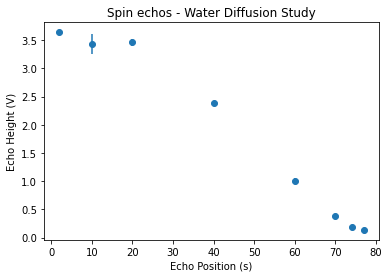

```python
plt.errorbar(exp3['echo pos (ms)'], [x.n for x in exp3['Echo height (V)']], \
             yerr = [x.s for x in exp3['Echo height (V)']], fmt='o')
plt.title('Spin echos - Water Diffusion Study')
plt.ylabel('Echo Height (V)')
plt.xlabel('Echo Position (s)')
```

### Fit it

Use the LMFit Model class to fit the data to equation (15) in the instructions. In this data set the number of pulses between the first FID and the echo, $n=1$. In your fit function, set the value of $T_2$ to be a constant (not a parameter that is adjustable by the fit), and set it to the $T_2$ value obtained for pure water.

Hint: to estimate a starting value for $K$, calculate the value of the function for the time $t$ at which it is half the height it is at $t=0$. This is like a "half-life" even though the decay is not a simple exponential.

```
[[Model]]
    Model(fit_function)
[[Fit Statistics]]
    # fitting method   = leastsq
    # function evals   = 25
    # data points      = 8
    # variables        = 2
    chi-square         = 135.306132
    reduced chi-square = 22.5510220
    Akaike info crit   = 26.6247865
    Bayesian info crit = 26.7836696
[[Variables]]
    Mi:  3.64475979 +/- 4.7551e-12 (0.00%) (init = 3.7)
    K:   7097.55013 +/- 7.6539e-08 (0.00%) (init = 1)
```

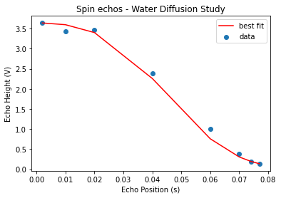

```python
## Define the fit function

T2_unc = unc.ufloat(709.3e-03,50e-3) # s
T2 = T2_unc.n
t = exp3['echo pos (ms)']*10**-3 #s
Mpeak = [x.n for x in exp3['Echo height (V)']]
Mi = 3.7 # V

#create fit function based on experiment instructions eq. 15

def fit_function(t, Mi, K):
    return Mi * np.exp(-t/T2) * np.exp(-K * t**3)


## pull in the Model class and set up the fit

from lmfit import Model

mpeak_model = Model(fit_function)
yerr = np.array([x.s for x in exp3['Echo height (V)']]) + 1e-12 #in order to avoid NaN errors
result = mpeak_model.fit(Mpeak, t=t, Mi=Mi, K=1, weights = 1/yerr )
print(result.fit_report())

## Fit and plot
plt.scatter(t, Mpeak, label='data')
plt.plot(t, result.best_fit, '-', label='best fit', color ='red')
plt.title('Spin echos - Water Diffusion Study')
plt.ylabel('Echo Height (V)')
plt.xlabel('Echo Position (s)')
plt.legend()
```

### Optional: Estimate the self-diffusion constant of water

According to equation (16) in the instructions,

$$ K = \frac{\gamma^2}{12}\left(\frac{\partial B_0}{\partial z}\right)^2 D$$

and $\gamma\Delta B_0 = \Delta\omega_0$, the spread of precession frequencies that determines $T_2^*$. From this information and the width of the simple free induction decay, you can use the result for $K$ to estimate $D$ the diffusion constant for water (at room temperature).

Try this, and compare your result against Hahn's: [Hahn, E. L., "Spin echoes", Phys. Rev., 80, 580-594 (1950)](http://courses.washington.edu/phys431/restricted/Hahn_PR80.pdf), p. 589.

```python
params = result.params

## define variables in equation above
gamma = 2.765e8 #rad / s T, from instructions

K = unc.ufloat(params['K'], params['K'].stderr)

dz = unc.ufloat(6e-3,0.1e-3) # m, measured diameter of tube

T2_star = unc.ufloat(240e-6,50e-6) #240e-6 # s, measured decay time

## from experiment instructions eq. 12
dB0 = (1/T2_star - 1/T2_unc)/gamma

D = (12/gamma**2) * (K / (dB0/dz)**2)

actual_D = 2e-5 #cm^2 / s (from Hahn)
error = (D - actual_D)/actual_D
```

```python
print("Variables to determine D: \n")
print('γ : {:.2e}'.format(gamma), ' rad/(s T)')
print('K : {:.2e}'.format(K), ' s^-3')
print('T2 : {:.2e}'.format(T2), 's')
print('dB0 : {:.2e}'.format(dB0), ' T')
print('gamma dB0/dz : {:.2e}'.format(gamma * dB0/dz), ' T/m')
```

[output not shown]

```python
print('self-diffusion constant of water: D = {:.2eP}'.format(D*10**4), 'cm^2 / s')
print('error relative to Hahn: {:.3g} %'.format(error*100))

# Note: this large difference relative to Hahn's value likely indicates some
# systematic error in our measurements, but we were unable to determine what
# this might be. The source of the error is most likely in our K value, as it
# is around 3 times larger than was found previously using this apparatus, but we
# took another set of measurements and found roughly the same value.
```

```
self-diffusion constant of water: D = (1.77±0.74)×10⁻³ cm^2 / s
error relative to Hahn: -99.1+/-0.4 %
```